# ‘Women’s March crowds’ vs Non-Trump Votes

Luke Wolcott

January 30, 2017

On Saturday January 21, 2017, the day after Trump’s inauguration, thousands of people protested around the US (and around the world). Previously I looked at cities with the largest protest crowds, adjusted by city population. Now I’ll compare statewide protest crowd totals to the election vote tallies.

Specifically, I ask the question: **What is the relationship between a state’s 1/21/17 protest total and the number of people who voted against Trump?**

### Crowd number data

Again, I’ll use data gathered by Jeremy Pressman and Erica Chenoweth, taken from this site on 1/24/2017:

`https://docs.google.com/spreadsheets/d/1xa0iLqYKz8x9Yc_rfhtmSOJQ2EGgeUVjvV4A8LsIaxY/htmlview?sle=true#`

I clean up this data a little, take out non-US protests, and group protests by state.

### Election tallies

`https://docs.google.com/spreadsheets/d/133Eb4qQmOxNvtesw2hdVns073R68EZx4SfCnP4IGQf8/htmlview?sle=true#gid=19`

I combine the votes for “Clinton” and “Others” into “NonTrump”, organized by state.

### State protest crowds versus Non-Trump election votes

Here is a plot of StateCrowd versus Non-Trump Votes, on a log10 scale, which allows you to see which state is where by hovering.

[interactive chart not shown]

We are interested in fitting a line to the data.

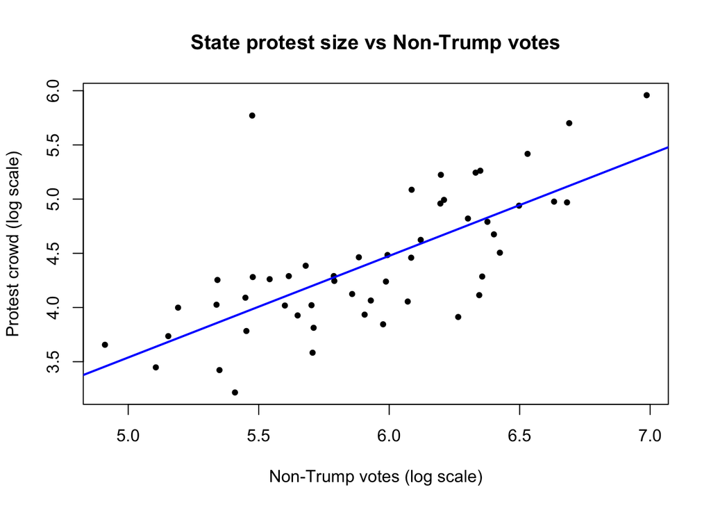

The fitted slope is 0.9375, which means that if State B has ten times as many non-Trump voters as State A, we would expect the crowd to be 10^(0.9375) = 8.66 times larger.

A non-log plot also shows the correlation.

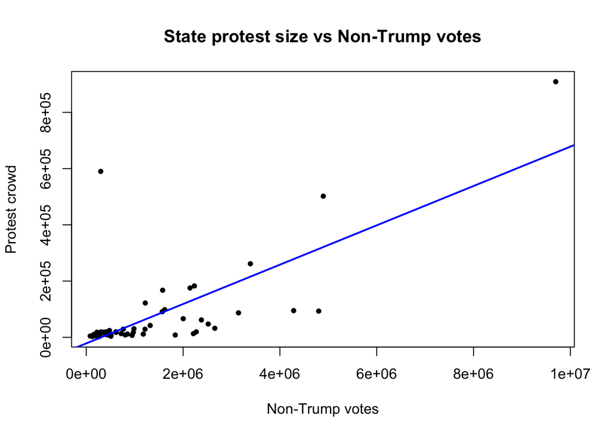

The slope for this fitted line is 0.06997, which we can interpret as saying that on average 7.00% of non-Trump voters attended the 1/21/2017 protest. (Except that the crowd estimates include non-voters, for example children.)

If we remove DC, we can more reasonably compare the 50 states. Here is a heatmap showing each state’s ratio of protest crowd to non-Trump votes.

[interactive chart not shown]